# Homework_2_Rino_Gwen

Gwen Rino

2/7/2018

```r
library(tidyverse)
library(gridExtra)
```

**R for Data Science Exercise 3.2.4**

1. The code `ggplot(data = mpg)` creates just an empty gray box.
2. Using `glimpse(mpg)`, I can see that there are 234 rows and 11 columns in the mpg dataset.
3. `drv` is a categorical variable with three levels: f = front-wheel drive, r = rear wheel drive, 4 = 4wd

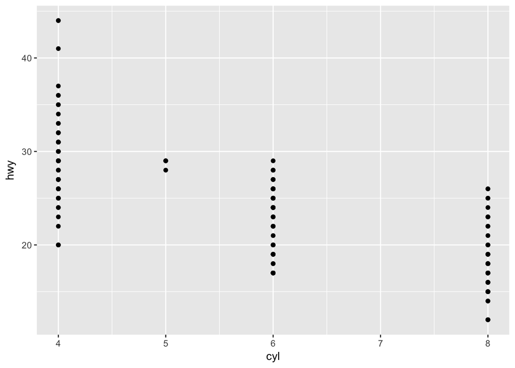

```r
ggplot(data = mpg) +
  geom_point(mapping = aes(x = cyl, y = hwy))
```

5. The plot below is not useful because both variables are categorical.

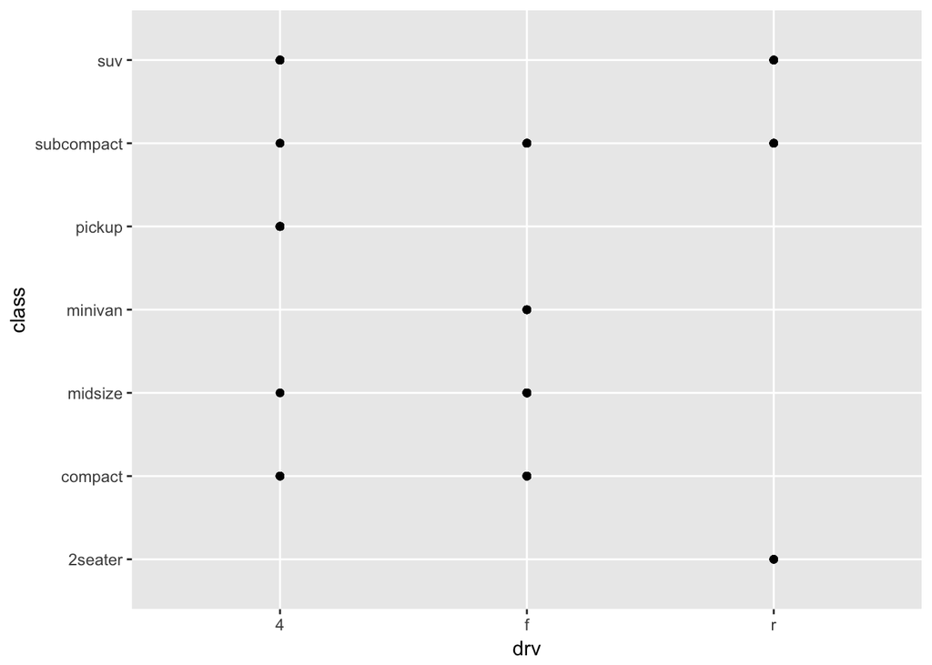

```r
ggplot(data = mpg) +
  geom_point(mapping = aes(x = drv, y = class))
```

**R for Data Science Exercise 3.3.1**

1. The code below is wrong because “color” is not mapped to a variable and so should not be inside the `aes()`.

```r
ggplot(data = mpg) +
  geom_point(mapping = aes(x = displ, y = hwy, color = "blue"))
```

2. You can see the variable type at the top of each column when you run `mpg`.

Categorical variables: manufacturer, model, year, cyl, trans, drv, fl, class  
Continuous variables: displ, cty, hwy

3. “Color” uses different gradients of the same color for continuous variables, and completely different colors for each level of a categorical variable. “Size” uses size gradients for continuous variables, while it assigns a different size point for each level of a categorical variable. “Shape” doesn’t work at all with continuous variables (which makes sense!).
4. When you map the same variable to multiple aesthetics, the variable is identified by more than one quality. In the plot below, each point’s fuel type is shown by both shape and color.

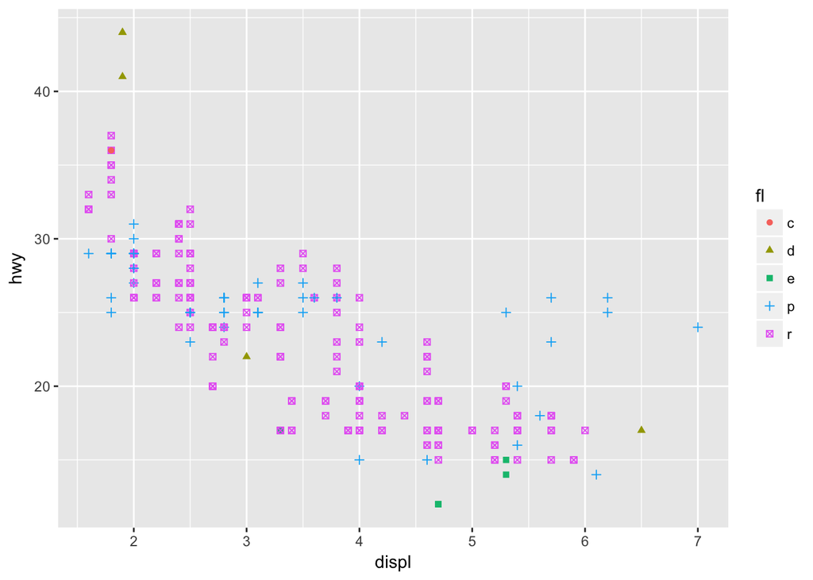

```r
ggplot(data = mpg) +
  geom_point(mapping = aes(x = displ, y = hwy, shape = fl, color = fl))
```

5. “Stroke” modifies the width of the border of shapes that have borders, as shown below.

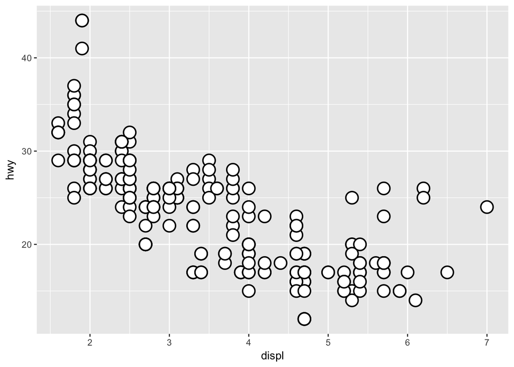

```r
ggplot(data = mpg) +
  geom_point(mapping = aes(x = displ, y = hwy, shape = cyl), shape = 21, color = "black", fill = "white", size = 5, stroke = 1)
```

6. This aesthetic `aes(color = displ < 5)` creates a plot in which the value of the displ variable (greater or less than 5) is distinguished by color, as shown below.

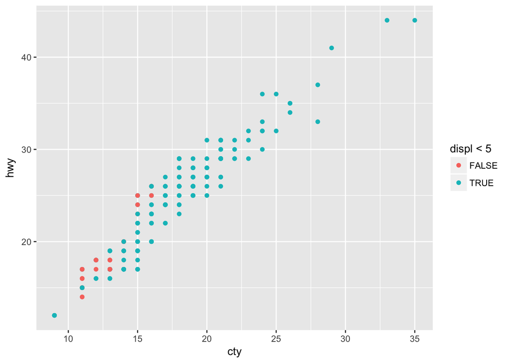

```r
ggplot(data = mpg) +
  geom_point(mapping = aes(x = cty, y = hwy, color = displ < 5))
```

**R for Data Science Exercise 3.5.1**